# Выбор локации для скважины

Добывающей компании «ГлавРосГосНефть» нужно решить, где бурить новую скважину.

Шаги для выбора локации:

- В избранном регионе ищут месторождения, для каждого определяют значения признаков;
- Строят модель и оценивают объём запасов;
- Выбирают месторождения с самым высокими оценками значений. Количество месторождений зависит от бюджета компании и стоимости разработки одной скважины;
- Прибыль равна суммарной прибыли отобранных месторождений.

## Загрузка и подготовка данных

```python
import numpy as np
import pandas as pd
import seaborn as sns
from matplotlib import pyplot as plt
from scipy import stats
from sklearn.linear_model import LinearRegression
from sklearn.metrics import mean_squared_error
from sklearn.model_selection import train_test_split
```

```python
import warnings
warnings.filterwarnings("ignore")
```

Исходные переменные:

```python
REGIONAL_BUDGET = 10 * 10**9 # Бюджет на разработку скважин в регионе
INCOME_PER_BARRELL = 450  # Доход с одного барреля сырья
INCOME_PER_UNIT = 450000 # Доход с каждой единицы продукта
OIL_WELLS = 500 #размер выборки скважин
SELECTED_WELLS = 200 # Количество лучших шахт для расчета прибыли
```

```python
df0 = pd.read_csv('datasets/geo_data_0.csv')
df1 = pd.read_csv('datasets/geo_data_1.csv')
df2 = pd.read_csv('datasets/geo_data_2.csv')

dfs = [df0, df1, df2]

for df in dfs:
    display(df.head())
```

|  | id | f0 | f1 | f2 | product |
| --- | --- | --- | --- | --- | --- |
| 0 | txEyH | 0.705745 | -0.497823 | 1.221170 | 105.280062 |
| 1 | 2acmU | 1.334711 | -0.340164 | 4.365080 | 73.037750 |
| 2 | 409Wp | 1.022732 | 0.151990 | 1.419926 | 85.265647 |
| 3 | iJLyR | -0.032172 | 0.139033 | 2.978566 | 168.620776 |
| 4 | Xdl7t | 1.988431 | 0.155413 | 4.751769 | 154.036647 |

|  | id | f0 | f1 | f2 | product |
| --- | --- | --- | --- | --- | --- |
| 0 | kBEdx | -15.001348 | -8.276000 | -0.005876 | 3.179103 |
| 1 | 62mP7 | 14.272088 | -3.475083 | 0.999183 | 26.953261 |
| 2 | vyE1P | 6.263187 | -5.948386 | 5.001160 | 134.766305 |
| 3 | KcrkZ | -13.081196 | -11.506057 | 4.999415 | 137.945408 |
| 4 | AHL4O | 12.702195 | -8.147433 | 5.004363 | 134.766305 |

|  | id | f0 | f1 | f2 | product |
| --- | --- | --- | --- | --- | --- |
| 0 | fwXo0 | -1.146987 | 0.963328 | -0.828965 | 27.758673 |
| 1 | WJtFt | 0.262778 | 0.269839 | -2.530187 | 56.069697 |
| 2 | ovLUW | 0.194587 | 0.289035 | -5.586433 | 62.871910 |
| 3 | q6cA6 | 2.236060 | -0.553760 | 0.930038 | 114.572842 |
| 4 | WPMUX | -0.515993 | 1.716266 | 5.899011 | 149.600746 |

```python
for df in dfs:
    display(df.info())
```

```
<class 'pandas.core.frame.DataFrame'>
RangeIndex: 100000 entries, 0 to 99999
Data columns (total 5 columns):
 #   Column   Non-Null Count   Dtype
---  ------   --------------   -----
 0   id       100000 non-null  object
 1   f0       100000 non-null  float64
 2   f1       100000 non-null  float64
 3   f2       100000 non-null  float64
 4   product  100000 non-null  float64
dtypes: float64(4), object(1)
memory usage: 3.8+ MB
```

```
None
```

```
<class 'pandas.core.frame.DataFrame'>
RangeIndex: 100000 entries, 0 to 99999
Data columns (total 5 columns):
 #   Column   Non-Null Count   Dtype
---  ------   --------------   -----
 0   id       100000 non-null  object
 1   f0       100000 non-null  float64
 2   f1       100000 non-null  float64
 3   f2       100000 non-null  float64
 4   product  100000 non-null  float64
dtypes: float64(4), object(1)
memory usage: 3.8+ MB
```

```
None
```

```
<class 'pandas.core.frame.DataFrame'>
RangeIndex: 100000 entries, 0 to 99999
Data columns (total 5 columns):
 #   Column   Non-Null Count   Dtype
---  ------   --------------   -----
 0   id       100000 non-null  object
 1   f0       100000 non-null  float64
 2   f1       100000 non-null  float64
 3   f2       100000 non-null  float64
 4   product  100000 non-null  float64
dtypes: float64(4), object(1)
memory usage: 3.8+ MB
```

```
None
```

Проверим данные на повторяющиеся значения в поле 'id'.

```python
for df in dfs:
    display(df[df['id'].duplicated(keep=False)].sort_values('id'))
```

|  | id | f0 | f1 | f2 | product |
| --- | --- | --- | --- | --- | --- |
| 66136 | 74z30 | 1.084962 | -0.312358 | 6.990771 | 127.643327 |
| 64022 | 74z30 | 0.741456 | 0.459229 | 5.153109 | 140.771492 |
| 51970 | A5aEY | -0.180335 | 0.935548 | -2.094773 | 33.020205 |
| 3389 | A5aEY | -0.039949 | 0.156872 | 0.209861 | 89.249364 |
| 69163 | AGS9W | -0.933795 | 0.116194 | -3.655896 | 19.230453 |
| 42529 | AGS9W | 1.454747 | -0.479651 | 0.683380 | 126.370504 |
| 931 | HZww2 | 0.755284 | 0.368511 | 1.863211 | 30.681774 |
| 7530 | HZww2 | 1.061194 | -0.373969 | 10.430210 | 158.828695 |
| 63593 | QcMuo | 0.635635 | -0.473422 | 0.862670 | 64.578675 |
| 1949 | QcMuo | 0.506563 | -0.323775 | -2.215583 | 75.496502 |
| 75715 | Tdehs | 0.112079 | 0.430296 | 3.218993 | 60.964018 |
| 21426 | Tdehs | 0.829407 | 0.298807 | -0.049563 | 96.035308 |
| 92341 | TtcGQ | 0.110711 | 1.022689 | 0.911381 | 101.318008 |
| 60140 | TtcGQ | 0.569276 | -0.104876 | 6.440215 | 85.350186 |
| 89582 | bsk9y | 0.398908 | -0.400253 | 10.122376 | 163.433078 |
| 97785 | bsk9y | 0.378429 | 0.005837 | 0.160827 | 160.637302 |
| 41724 | bxg6G | -0.823752 | 0.546319 | 3.630479 | 93.007798 |
| 1364 | bxg6G | 0.411645 | 0.856830 | -3.653440 | 73.604260 |
| 16633 | fiKDv | 0.157341 | 1.028359 | 5.585586 | 95.817889 |
| 90815 | fiKDv | 0.049883 | 0.841313 | 6.394613 | 137.346586 |

|  | id | f0 | f1 | f2 | product |
| --- | --- | --- | --- | --- | --- |
| 5849 | 5ltQ6 | -3.435401 | -12.296043 | 1.999796 | 57.085625 |
| 84461 | 5ltQ6 | 18.213839 | 2.191999 | 3.993869 | 107.813044 |
| 1305 | LHZR0 | 11.170835 | -1.945066 | 3.002872 | 80.859783 |
| 41906 | LHZR0 | -8.989672 | -4.286607 | 2.009139 | 57.085625 |
| 2721 | bfPNe | -9.494442 | -5.463692 | 4.006042 | 110.992147 |
| 82178 | bfPNe | -6.202799 | -4.820045 | 2.995107 | 84.038886 |
| 47591 | wt4Uk | -9.091098 | -8.109279 | -0.002314 | 3.179103 |
| 82873 | wt4Uk | 10.259972 | -9.376355 | 4.994297 | 134.766305 |

|  | id | f0 | f1 | f2 | product |
| --- | --- | --- | --- | --- | --- |
| 45404 | KUPhW | 0.231846 | -1.698941 | 4.990775 | 11.716299 |
| 55967 | KUPhW | 1.211150 | 3.176408 | 5.543540 | 132.831802 |
| 11449 | VF7Jo | 2.122656 | -0.858275 | 5.746001 | 181.716817 |
| 49564 | VF7Jo | -0.883115 | 0.560537 | 0.723601 | 136.233420 |
| 44378 | Vcm5J | -1.229484 | -2.439204 | 1.222909 | 137.968290 |
| 95090 | Vcm5J | 2.587702 | 1.986875 | 2.482245 | 92.327572 |
| 28039 | xCHr8 | 1.633027 | 0.368135 | -2.378367 | 6.120525 |
| 43233 | xCHr8 | -0.847066 | 2.101796 | 5.597130 | 184.388641 |

В данных имеется незначительное количество строк с повторяющимися 'id'.

Посмотрим на распределение параметров методом .pairplot().

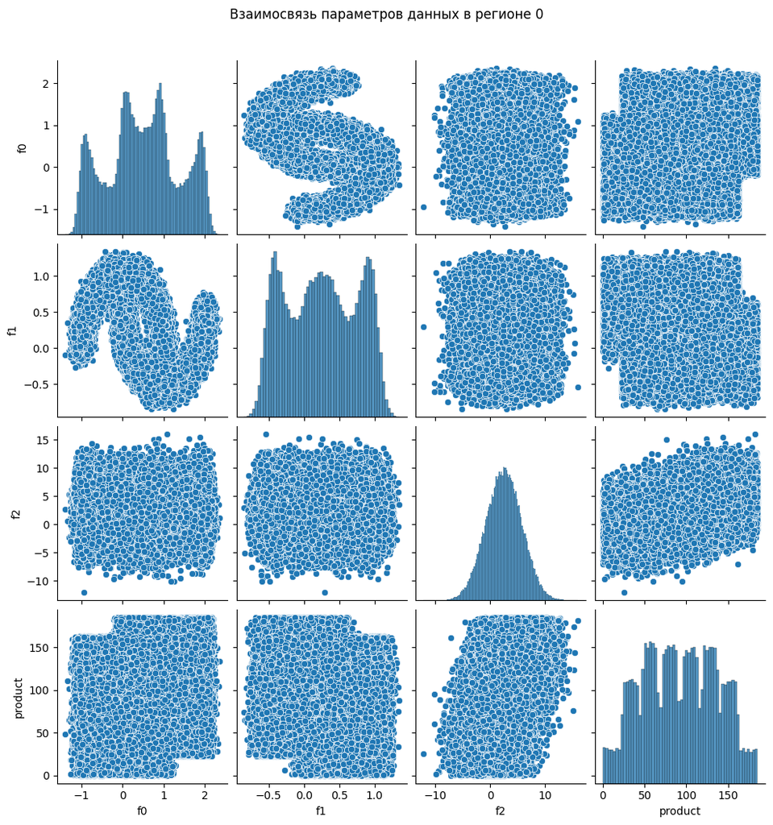

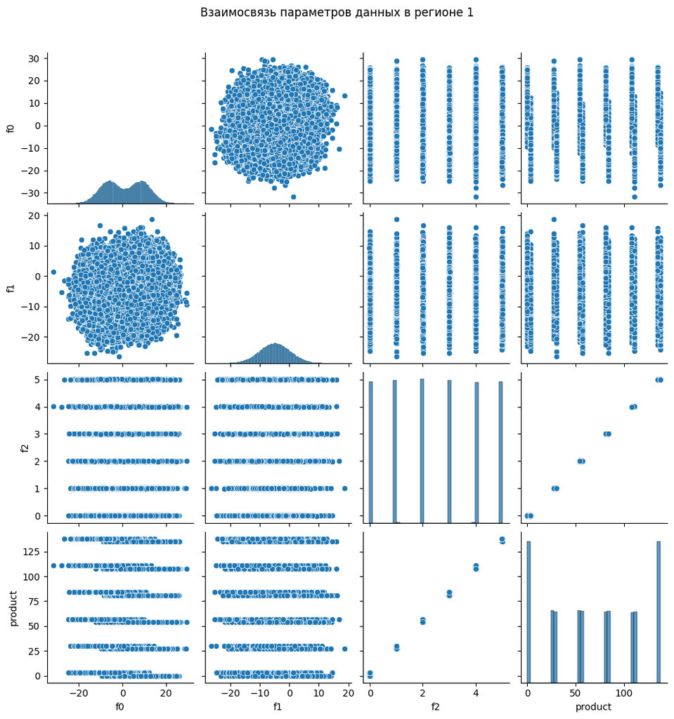

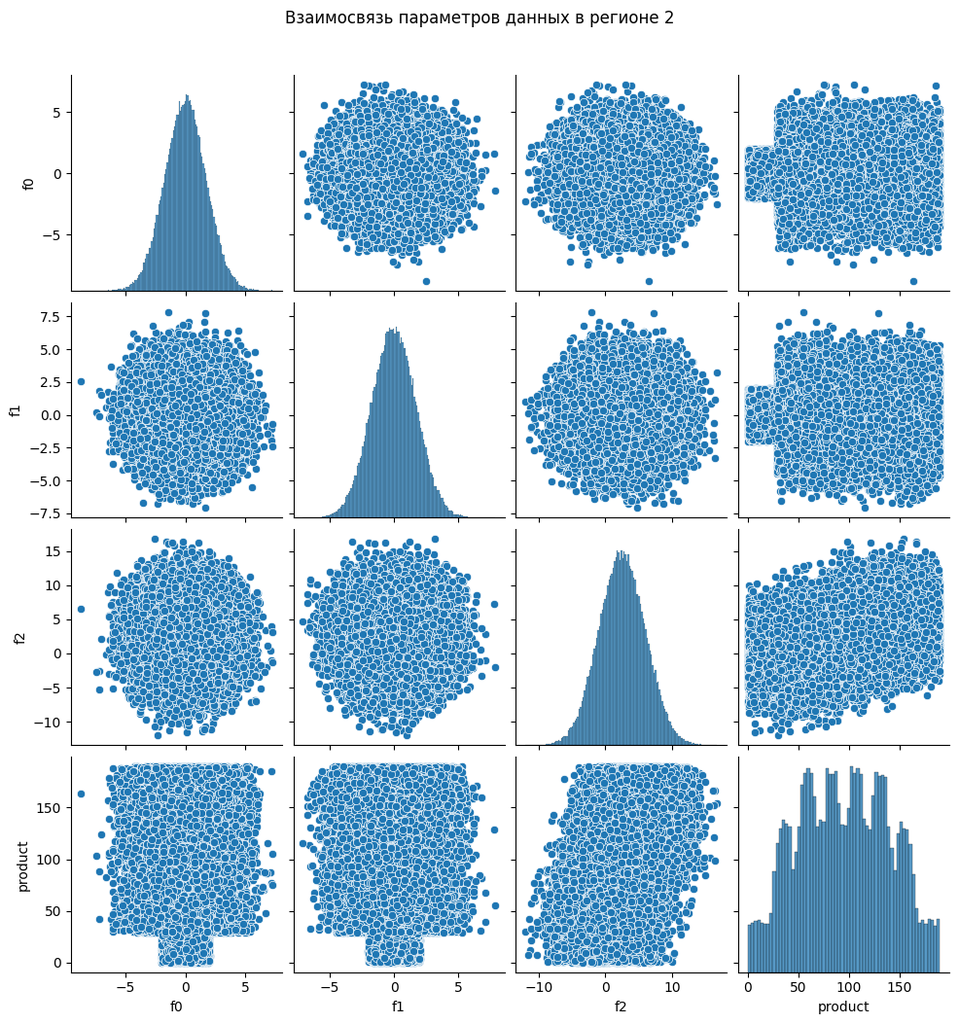

```python
for i, df in enumerate(dfs):
    sns.pairplot(df).fig.suptitle(f'Взаимосвязь параметров данных в регионе {i}', y=1.05)
    plt.show
```

Данные очищены от аномалий и подготовлены для обучения моделей, в регионе 1 заметна чёткая корреляция целевого показателя 'product' по параметру 'f2'.

Проверим параметры на взаимную корреляцию.

```python
for df in dfs:
    display(df.drop('id', axis=1).corr())
```

|  | f0 | f1 | f2 | product |
| --- | --- | --- | --- | --- |
| f0 | 1.000000 | -0.440723 | -0.003153 | 0.143536 |
| f1 | -0.440723 | 1.000000 | 0.001724 | -0.192356 |
| f2 | -0.003153 | 0.001724 | 1.000000 | 0.483663 |
| product | 0.143536 | -0.192356 | 0.483663 | 1.000000 |

|  | f0 | f1 | f2 | product |
| --- | --- | --- | --- | --- |
| f0 | 1.000000 | 0.182287 | -0.001777 | -0.030491 |
| f1 | 0.182287 | 1.000000 | -0.002595 | -0.010155 |
| f2 | -0.001777 | -0.002595 | 1.000000 | 0.999397 |
| product | -0.030491 | -0.010155 | 0.999397 | 1.000000 |

|  | f0 | f1 | f2 | product |
| --- | --- | --- | --- | --- |
| f0 | 1.000000 | 0.000528 | -0.000448 | -0.001987 |
| f1 | 0.000528 | 1.000000 | 0.000779 | -0.001012 |
| f2 | -0.000448 | 0.000779 | 1.000000 | 0.445871 |
| product | -0.001987 | -0.001012 | 0.445871 | 1.000000 |

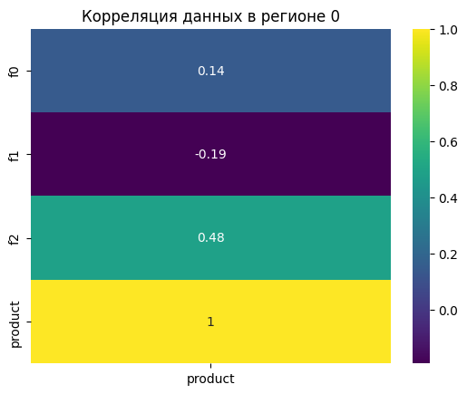

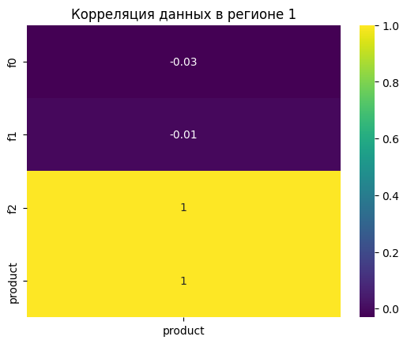

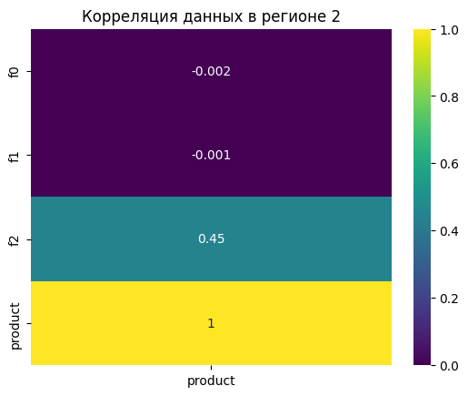

```python
for i, df in enumerate(dfs):
    ax = plt.axes()
    sns.heatmap(df.drop('id', axis=1).corr()[['product']], annot = True, cmap = 'viridis', ax = ax)

    ax.set_title(f'Корреляция данных в регионе {i}')
    plt.show()
```

Как было замечено выше, в регионе 1 корреляция целевого параметра 'product' с параметром 'f2' очень сильна и почти равна 1.

Для обучения модели избавимcя от выявленных повторов и очистим датасет от признака 'id'.

```python
for i in range(len(dfs)):
    dfs[i] = dfs[i].drop_duplicates('id', keep=False)
```

```python
for i in range(len(dfs)):
    dfs[i] = dfs[i].drop('id', axis=1)
```

## Обучение и проверка модели

Создадим функцию, которая будет принимать на вход датасет, название целевого параметра и размер валидационной выборки, рассчитывать средний запас сырья и среднеквадратичное отклонение по валидационной выборке и возвращать обученную модель и список с выборками.

```python
def linear_model_creator(data, target_name, valid_size):
    target = data[target_name]
    features = data.drop(target_name, axis=1)

    features_train, features_valid, target_train, target_valid = \
train_test_split(features, target, test_size=valid_size)

    samples = [features_train, features_valid, target_train, target_valid]
    samples_names = ['features_train', 'features_valid', 'target_train', 'target_valid']

    for i in range(len(samples)):
        print(samples_names[i], samples[i].shape)
    print('\n')

    model = LinearRegression().fit(features_train, target_train)
    target_predicted = model.predict(features_valid)
    result = mean_squared_error(target_valid, target_predicted) ** 0.5

    print('Средний запас предсказанного сырья', target_predicted.mean())
    print("RMSE модели линейной регрессии на валидационной выборке:", result)
    print('-----------------------------------------------------------------------------------', '\n')

    return model, [features_train, features_valid, target_train, target_valid, target_predicted]
```

Применим эту функцию для датасетов.

```python
region_models = [] # список для хранения моделей по регионам
region_data = [] # список для хранения выборок по регионам

for i in range(len(dfs)):
    print('Регион', i, '\n')
    model, array = linear_model_creator(dfs[i], 'product', 0.25)
    region_models.append(model)
    region_data.append(array)
```

```
Регион 0

features_train (74985, 3)
features_valid (24995, 3)
target_train (74985,)
target_valid (24995,)


Средний запас предсказанного сырья 92.72631174687609
RMSE модели линейной регрессии на валидационной выборке: 37.69585723049686
-----------------------------------------------------------------------------------

Регион 1

features_train (74994, 3)
features_valid (24998, 3)
target_train (74994,)
target_valid (24998,)


Средний запас предсказанного сырья 68.82008573014085
RMSE модели линейной регрессии на валидационной выборке: 0.8899037005370947
-----------------------------------------------------------------------------------

Регион 2

features_train (74994, 3)
features_valid (24998, 3)
target_train (74994,)
target_valid (24998,)


Средний запас предсказанного сырья 95.0945723083584
RMSE модели линейной регрессии на валидационной выборке: 40.09057102940517
-----------------------------------------------------------------------------------
```

В регионе 1 средний запас заметно меньше, чем в региона 0 и 2, но среднеквадратичное отклонение в этом регионе на несколько порядков меньше, что говорит об очень точном прогнозировании запасов моделью этого региона, это скорее всего связано с выявленной выше корреляцией по параметру 'f2'.

## Подготовка к расчёту прибыли

Исходя из имеющегося бюджета (на разработку 200 скважин), рассчитаем необходимый запас сырья в скважине для безубыточной разработки.

```python
minimal_volume = REGIONAL_BUDGET / INCOME_PER_UNIT # Минимальный запас нефти для окупаемости разработки
well_volume = minimal_volume / SELECTED_WELLS
print('Минимальный сырья в скважине', round(well_volume), 'тыс. баррелей.')
```

```
Минимальный сырья в скважине 111 тыс. баррелей.
```

```python
for i in range(len(dfs)):
    if dfs[i]['product'].mean() < well_volume:
        print('Средний запас сырья в регионе', i, 'меньше минимально требуемого для окупаемости разработки.')
    else:
        print('Средний запас сырья в регионе', i, 'достаточен для окупаемости разработки.')
```

```
Средний запас сырья в регионе 0 меньше минимально требуемого для окупаемости разработки.
Средний запас сырья в регионе 1 меньше минимально требуемого для окупаемости разработки.
Средний запас сырья в регионе 2 меньше минимально требуемого для окупаемости разработки.
```

Средний запас сырья во всех регионах ниже минимально требуемого, а значит нужно ответственно подойти к выбору разрабатываемых скважин, чтобы избежать убытков.

## Расчёт прибыли по выбранным скважинам и предсказаниям модели

```python
def revenue_calc(data_valid, data_predicted):
    target_predicted = pd.Series(data_predicted).reset_index(drop=True)
    target_valid = pd.Series(data_valid).reset_index(drop=True)

    predictions_sorted = target_predicted.sort_values(ascending=False)
    target_200 = target_valid[predictions_sorted.index][:200]


    #top_wells = df.sort_values('product', ascending=False)[:OIL_WELLS]

    #top_predicted = pd.Series(model.\
    #                          predict(top_wells.drop('product', axis=1))).\
    #sort_values(ascending=False)[:SELECTED_WELLS].\
    #sum()

    revenue = target_200.sum() * INCOME_PER_UNIT - REGIONAL_BUDGET
    return revenue
```

```python
for i in range(len(region_data)):
    data_valid = region_data[i][-2]
    data_predicted = region_data[i][-1]
    print('Расчётная прибыль в регионе', i, '-', round(revenue_calc(data_valid, data_predicted)/ 10 ** 9, 3), 'млрд рублей')
```

```
Расчётная прибыль в регионе 0 - 3.329 млрд рублей
Расчётная прибыль в регионе 1 - 2.415 млрд рублей
Расчётная прибыль в регионе 2 - 2.523 млрд рублей
```

Максимально возможную прибыль можно прогнозировать в регионе 0.

## Расчёт прибыли и рисков

Применим технику bootstrap для расчёта возможной прибыли и рисков при выборе разных наборов скважин для разработки.

```python
state = np.random.RandomState(12345)
for j in range(len(dfs)):
    revenues = []
    print('Регион', j)
    print()

    for i in range(1000):
        target_valid = pd.Series(region_data[j][-2]).reset_index(drop=True)
        target_predicted = pd.Series(region_data[j][-1]).reset_index(drop=True)

        subsample_valid = target_valid.sample(n=OIL_WELLS, replace=True, random_state=state)
        subsample_target = target_predicted[subsample_valid.index]

        revenues.append(revenue_calc(subsample_valid, subsample_target))

    revenues = pd.Series(revenues)
    print('Средняя прибыль', round(revenues.mean()/10 ** 9, 3), 'млрд рублей.')
    print('95%-й доверительный интервал:', \
          round(revenues.quantile(0.025)/10 ** 9, 3),\
          '-',\
          round(revenues.quantile(0.975)/10 ** 9, 3),\
          'млрд рублей.')
    print('Риск убытков', stats.percentileofscore(revenues, 0), '%')
    print('-----------------------------------------------------------------------------------------')
    print()
```

```
Регион 0

Средняя прибыль 0.417 млрд рублей.
95%-й доверительный интервал: -0.146 - 0.931 млрд рублей.
Риск убытков 6.0 %
-----------------------------------------------------------------------------------------

Регион 1

Средняя прибыль 0.454 млрд рублей.
95%-й доверительный интервал: 0.016 - 0.85 млрд рублей.
Риск убытков 2.3000000000000003 %
-----------------------------------------------------------------------------------------

Регион 2

Средняя прибыль 0.404 млрд рублей.
95%-й доверительный интервал: -0.117 - 0.921 млрд рублей.
Риск убытков 7.300000000000001 %
-----------------------------------------------------------------------------------------
```

В регионе 1 прогнозируется максимальная средняя прибыль, также нижняя граница 95%-го доверительного интервала там выше, чем в остальных регионах, а риски убытков минимальны.

На основании проведённых расчётов можно рекомендовать для разработки регион 1, т.к. в нём максимальная средняя прибыль и минимальные риски.